# Семинар 3.

## Свойства оценок. Оценка параметров по методу максимального правдоподобия

```python
import numpy as np
import matplotlib.pyplot as plt
import scipy.stats as stats
import pandas as pd
import seaborn as sns
```

### Робастность

Оценка называется робастной, если она устойчива к выбросам и небольшим отклонениям от предположений модели.

Пример:

- Среднее не робастно, так как сильно реагирует на выбросы.
- Медиана робастна, так как остаётся стабильной даже при наличии выбросов.

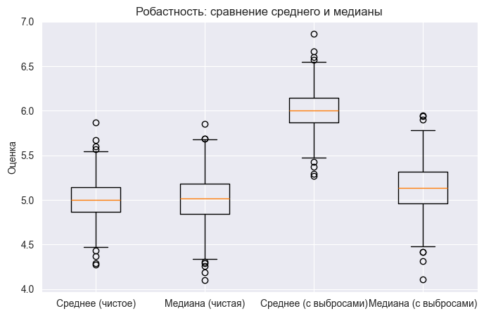

```python
np.random.seed(42)

mu, sigma = 5, 2
n = 100
num_experiments = 1000

means_clean, medians_clean = [], []
means_with_outliers, medians_with_outliers = [], []

for _ in range(num_experiments):
    # Чистая выборка
    sample = np.random.normal(mu, sigma, size=n)
    means_clean.append(np.mean(sample))
    medians_clean.append(np.median(sample))

    # Выборка с выбросами (добавляем аномально большие значения)
    sample_with_outliers = np.copy(sample)
    sample_with_outliers[:5] += 20  # Добавляем 5 больших выбросов
    means_with_outliers.append(np.mean(sample_with_outliers))
    medians_with_outliers.append(np.median(sample_with_outliers))

# Визуализация
plt.figure(figsize=(8, 5))
plt.boxplot([means_clean, medians_clean, means_with_outliers, medians_with_outliers],
            tick_labels=["Среднее (чистое)", "Медиана (чистая)", "Среднее (с выбросами)", "Медиана (с выбросами)"])
plt.title("Робастность: сравнение среднего и медианы")
plt.ylabel("Оценка")
plt.show()
```

### Эффективность

Оценка эффективна, если она имеет минимальную дисперсию среди всех несмещённых оценок.

Пример: Оценка математического ожидания средним из нормального распределения является эффективной, так как её дисперсия минимальна.

Сравним среднее и медиану.

```python
sample_size = 100
num_experiments = 10000

sample_means = []
median_estimates = []

for _ in range(num_experiments):
    sample = np.random.normal(mu, sigma, size=sample_size)
    sample_means.append(np.mean(sample))  # Среднее (эффективная оценка)
    median_estimates.append(np.median(sample))  # Медиана (неэффективная, но робастная)

# Вычисляем дисперсии
var_mean = np.var(sample_means)
var_median = np.var(median_estimates)

print(f"Дисперсия оценки среднего: {var_mean:.6f}")
print(f"Дисперсия оценки медианы: {var_median:.6f}")
print(f"Отношение дисперсий (медиана/среднее): {var_median / var_mean:.2f}")
```

```
Дисперсия оценки среднего: 0.040262
Дисперсия оценки медианы: 0.062849
Отношение дисперсий (медиана/среднее): 1.56
```

### Асимптотическая нормальность

Если оценка $\hat{\theta_n}$ асимптотически нормальна, то:

$$ \sqrt{n}(\hat{\theta_n} - \theta_n) \to N(0, \sigma^2) $$

То есть, при большом $n$ оценка приближается к нормальному распределению.

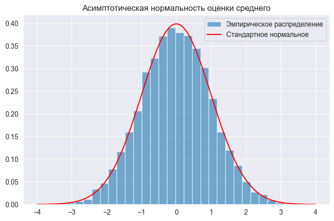

```python
sample_size = 100
num_experiments = 10000
theta_estimates = []

for _ in range(num_experiments):
    sample = np.random.normal(mu, sigma, size=sample_size)
    theta_estimates.append(np.mean(sample))

# Нормализуем оценки
normalized_estimates = np.sqrt(sample_size) * (np.array(theta_estimates) - mu) / sigma

# Гистограмма
plt.figure(figsize=(8, 5))
plt.hist(normalized_estimates, bins=30, density=True, alpha=0.6, label="Эмпирическое распределение")
x_vals = np.linspace(-4, 4, 100)
plt.plot(x_vals, stats.norm.pdf(x_vals, loc=0, scale=1), label="Стандартное нормальное", color="r")
plt.legend()
plt.title("Асимптотическая нормальность оценки среднего")
plt.show()
```

### Оценка максимального правдоподобия

#### Идея

Оценка максимального правдоподобия (ОМП) — это метод статистической оценки параметров модели, при котором выбирается такое значение параметра, которое максимизирует функцию правдоподобия.

Пусть у нас есть случайная выборка $X_1, X_2, X_3, \dots, X_n$, которая подчиняется распределению с неизвестным параметром $\theta$.

Функция правдоподобия — это вероятность (или плотность) наблюдаемых данных при данном параметре: $$ L(\theta) = P(X_1, X_2, \dots, X_n | \theta) $$

Или в случае непрерывного распределения: $$ L(\theta) = \prod_{i=1}^{n} f(X_i | \theta) $$ (по независимости случайных величин функция распадается в произведение вероятностей)

Чтобы найти оценку максимального правдоподобия $\hat{\theta}$, необходимо максимизировать $$ l(\theta) = \ln L(\theta) = \sum_{i = 1}^{n} f(X_i | \theta) $$

Далее берём производную по $\theta$, приравниваем её к нулю и решаем уравнение: $$ \frac{d l(\theta)}{d \theta} = 0 $$

### Поиск ОМП аналитически

Пусть $X_1, X_2, \dots, X_n \sim N(\mu, \sigma^2)$.

Найдем $\hat{\mu}$.

Функция правдоподобия:

$$ L(\mu) = \prod_{i=1}^{n} \frac{1}{\sqrt{2 \pi \sigma^2}} e ^ {- \frac{(X_i - \mu)^2}{2 \sigma^2}} $$

После логарифмирования:

$$ l(\mu) = - \frac{n}{2} \ln(2 \pi \sigma^2) - \frac{1}{2 \sigma^2} \sum_{i = 1}^{n} (X_i - \mu)^2 $$

Берем производную по $\mu$: $$ \frac{d l(\mu)}{d \mu} = \frac{1}{\sigma^2} \sum_{i = 1}^{n} (X_i - \mu) $$

Приравниваем к нулю: $$ \sum_{i = 1}^{n} (X_i - \mu) = 0 $$

Получаем: $$ \hat\mu = \frac{1}{n} \sum_{i = 1}^{n} X_i $$

То есть оценка максимального правдоподобия для математического ожидания — это просто выборочное среднее.

### Теорема о согласии эмпирического и генерального распределения

Эта теорема утверждает, что эмпирическая функция распределения, построенная по выборке, сходится к истинной (генеральной) функции распределения, как размер выборки $n \to \infty$.

Это фундаментальное свойство статистики, которое показывает, что, имея достаточно данных, мы можем хорошо аппроксимировать истинное распределение.

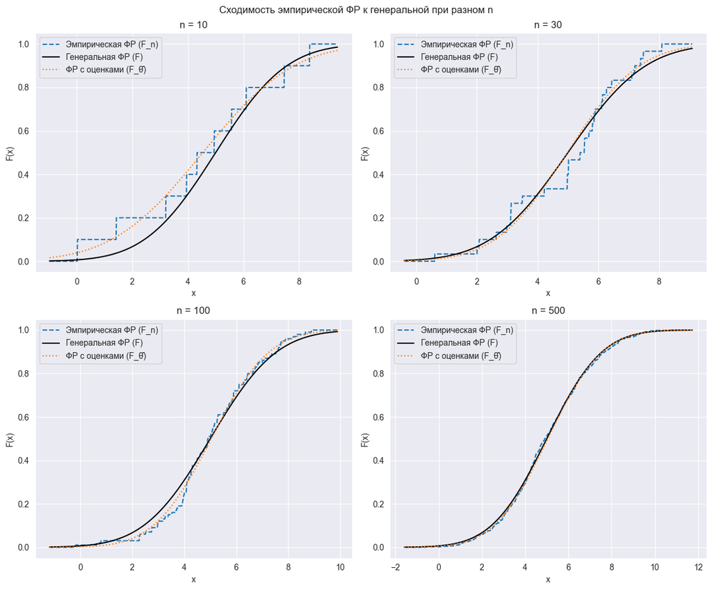

```python
# Истинные параметры распределения
mu, sigma = 5, 2

# Разные размеры выборок
sample_sizes = [10, 30, 100, 500]

# Создаем графики
fig, axes = plt.subplots(2, 2, figsize=(12, 10))

for i, n in enumerate(sample_sizes):
    # Генерируем выборку
    data = np.random.normal(mu, sigma, size=n)

    # Строим эмпирическую функцию распределения
    x_vals = np.linspace(min(data) - 1, max(data) + 1, 1000)
    ecdf = np.array([np.sum(data <= x) / n for x in x_vals])

    # Теоретическая функция распределения
    true_cdf = stats.norm.cdf(x_vals, loc=mu, scale=sigma)

    # Оценка параметров методом максимального правдоподобия
    mu_hat, sigma_hat = np.mean(data), np.std(data, ddof=1)
    estimated_cdf = stats.norm.cdf(x_vals, loc=mu_hat, scale=sigma_hat)

    # Выбираем соответствующую ось
    ax = axes[i // 2, i % 2]

    # Построение графиков
    ax.plot(x_vals, ecdf, label="Эмпирическая ФР (F_n)", linestyle="dashed")
    ax.plot(x_vals, true_cdf, label="Генеральная ФР (F)", color="black")
    ax.plot(x_vals, estimated_cdf, label="ФР с оценками (F_θ̂)", linestyle="dotted")

    # Настройки графика
    ax.set_title(f"n = {n}")
    ax.set_xlabel("x")
    ax.set_ylabel("F(x)")
    ax.legend()

plt.suptitle("Сходимость эмпирической ФР к генеральной при разном n")
plt.tight_layout()
plt.show()
```

```
    Height     Weight        Age  Sex  Race
1  172.212  75.296272  17.500000    0     1
2  160.020  42.184056  12.000000    1     0
3  127.254  24.493968   9.916667    0     0
4  141.478  31.297848  10.833333    1     0
5  160.528  52.163080  13.083333    0     0
```

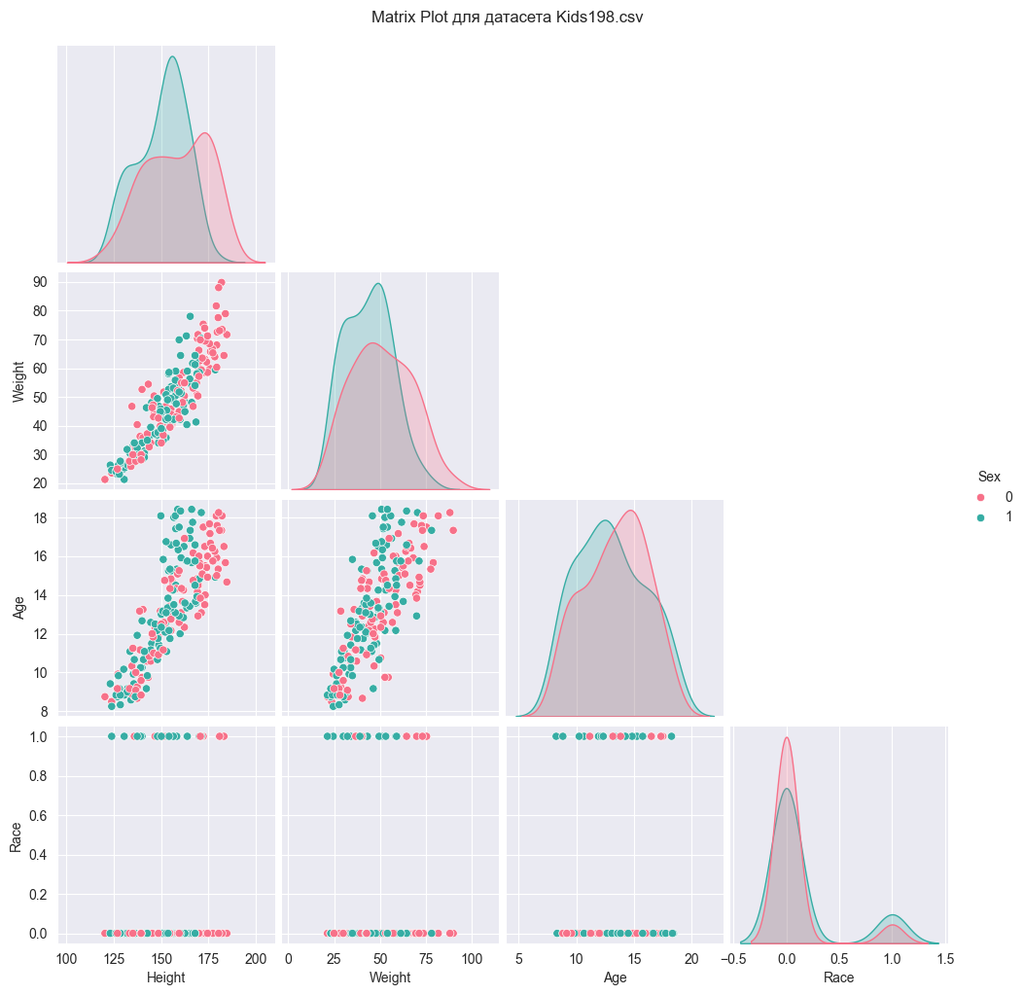

```python
import pandas as pd
import seaborn as sns
import matplotlib.pyplot as plt

# Загрузка данных
data = pd.read_csv('Kids198.csv', index_col=0)

# Исправленные преобразования единиц измерения
data['Height'] = data['Height'] * 2.54  # Дюймы в сантиметры
data['Age'] = data['Age'] / 12  # Месяцы в годы
data['Weight'] = data['Weight'] * 0.453592  # Фунты в килограммы

# Вывод первых строк для проверки
print(data.head())

# Построение матрицы рассеяния
sns.pairplot(data, diag_kind='kde', corner=True, hue='Sex', palette='husl')

plt.suptitle('Matrix Plot для датасета Kids198.csv', y=1.02)
plt.show()
```

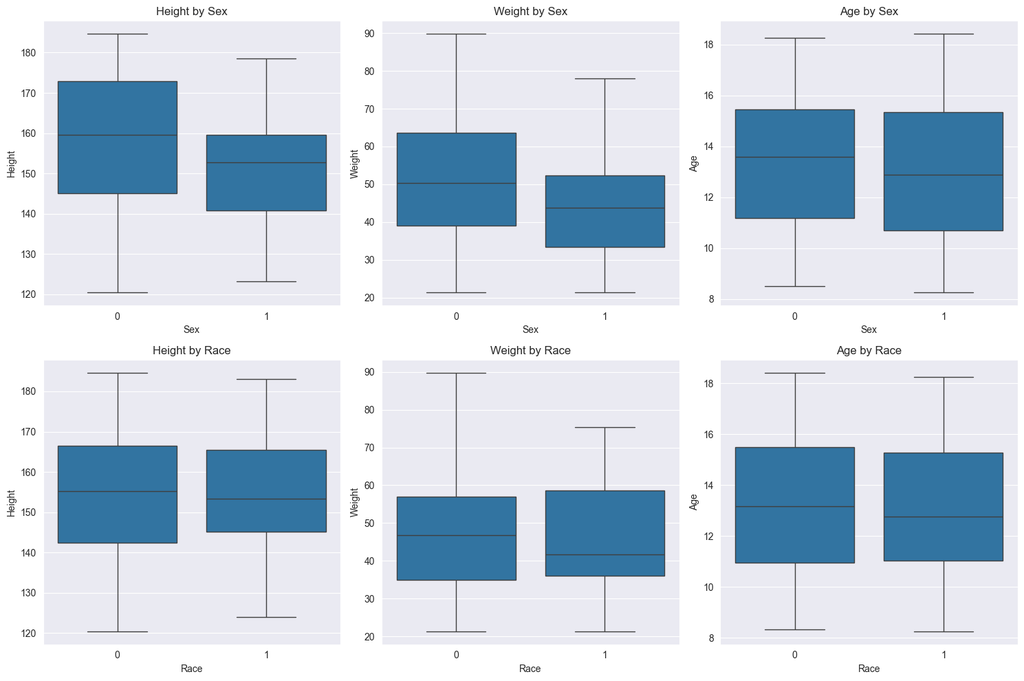

```python
# Настройка графиков
fig, axes = plt.subplots(2, 3, figsize=(15, 10))

# Boxplots по Sex
sns.boxplot(x="Sex", y="Height", data=data, ax=axes[0, 0])
axes[0, 0].set_title("Height by Sex")

sns.boxplot(x="Sex", y="Weight", data=data, ax=axes[0, 1])
axes[0, 1].set_title("Weight by Sex")

sns.boxplot(x="Sex", y="Age", data=data, ax=axes[0, 2])
axes[0, 2].set_title("Age by Sex")

# Boxplots по Race
sns.boxplot(x="Race", y="Height", data=data, ax=axes[1, 0])
axes[1, 0].set_title("Height by Race")

sns.boxplot(x="Race", y="Weight", data=data, ax=axes[1, 1])
axes[1, 1].set_title("Weight by Race")

sns.boxplot(x="Race", y="Age", data=data, ax=axes[1, 2])
axes[1, 2].set_title("Age by Race")

# Отображение графиков
plt.tight_layout()
plt.show()
```

### Правило трех сигм

Правило трёх сигм гласит, что для нормального распределения:

- 68.3% значений лежат в пределах 1 $\sigma$
- 95.4% значений лежат в пределах 2 $\sigma$
- 99.7% значений лежат в пределах 3 $\sigma$

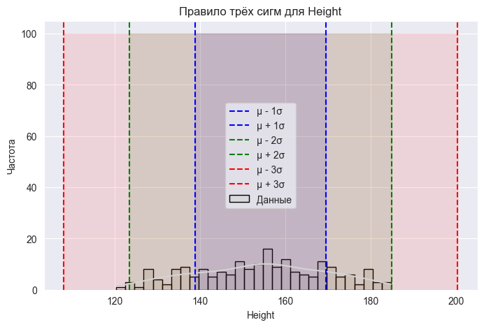

```
1σ: 63.13% данных
2σ: 98.99% данных
3σ: 100.00% данных
```

```python
feature = 'Height'
mu, sigma = data[feature].mean(), data[feature].std()

# Определяем границы 1σ, 2σ, 3σ
sigma_ranges = [1, 2, 3]
colors = ['blue', 'green', 'red']

# Визуализация гистограммы и областей трёх сигм
plt.figure(figsize=(8, 5))
sns.histplot(data[feature], bins=30, kde=True, color='lightgray', edgecolor='black', label='Данные')

for i, c in zip(sigma_ranges, colors):
    lower, upper = mu - i * sigma, mu + i * sigma
    plt.axvline(lower, color=c, linestyle='dashed', label=f'μ - {i}σ')
    plt.axvline(upper, color=c, linestyle='dashed', label=f'μ + {i}σ')
    plt.fill_betweenx([0, 100], lower, upper, color=c, alpha=0.1)

# Настройки графика
plt.title(f'Правило трёх сигм для {feature}')
plt.xlabel(feature)
plt.ylabel('Частота')
plt.legend()
plt.show()

# Проверка процентного содержания данных в пределах 1σ, 2σ, 3σ
for i in sigma_ranges:
    count_in_range = ((data[feature] >= mu - i * sigma) & (data[feature] <= mu + i * sigma)).mean() * 100
    print(f'{i}σ: {count_in_range:.2f}% данных')
```